# MSDS 458 Assignment 2 (Experiment 4) April 26 part 2

DATE: April 27, 2020

## Assignment 2:

The goal is to compare `DNN` and `CNN` for fashion mnist data.

In all the experiments, we would hold some parameters constants - the batch size to 100, the number of epochs to 20, same optimizer, same loss function of cross entropy, so that we can do fair comparisons.

- Expt 1: DNN with 2 layers (no drop out)
- Expt 2: DNN with 3 layers (no drop out)
- Expt 3: CNN with 2 convolution/max pooling layers (no drop out)
- **Expt 4: CNN with 3 convolution/max pooling layers (no drop out)**
- Expt 5: Redo all the 4 experiments with 20% drop out

`Result1`: Create a table with the accuracy and loss for train/test/validation & process time for all the 8 models

**`Result2`: Take Expt 3 – Extract the outputs from 2 selected filters from the 2 max pooling layers and visualize them in a grid as Images. See whether the lit up regions correspond to some features in the original images.**

**Result 2:** Let us visual every channel in every intermediate activation.

See https://github.com/fchollet/deep-learning-with-python-notebooks/blob/master/5.4-visualizing-what-convnets-learn.ipynb

```python
import matplotlib.pyplot as plt
import tensorflow as tf
tf.compat.v1.disable_eager_execution() # ADDED FOR EXPERIMENTAL PART
from tensorflow import keras
keras.__version__
```

```
'2.2.4-tf'
```

```python
from tensorflow.keras.models import load_model

model = load_model('experiment3.h5')
model.summary()  # As a reminder.
```

```
WARNING:tensorflow:From /Users/EdwardArroyo/anaconda3/envs/laptop_env/lib/python3.7/site-packages/tensorflow_core/python/ops/resource_variable_ops.py:1635: calling BaseResourceVariable.__init__ (from tensorflow.python.ops.resource_variable_ops) with constraint is deprecated and will be removed in a …
Instructions for updating:
If using Keras pass *_constraint arguments to layers.
Model: "sequential"
_________________________________________________________________
Layer (type)                 Output Shape              Param #
=================================================================
conv2d (Conv2D)              (None, 26, 26, 32)        320
_________________________________________________________________
max_pooling2d (MaxPooling2D) (None, 13, 13, 32)        0
_________________________________________________________________
conv2d_1 (Conv2D)            (None, 11, 11, 64)        18496
_________________________________________________________________
max_pooling2d_1 (MaxPooling2 (None, 5, 5, 64)          0
_________________________________________________________________
flatten (Flatten)            (None, 1600)              0
_________________________________________________________________
dense (Dense)                (None, 512)               819712
_________________________________________________________________
dense_1 (Dense)              (None, 10)                5130
=================================================================
Total params: 843,658
Trainable params: 843,658
Non-trainable params: 0
_________________________________________________________________
```

```python
# https://www.tensorflow.org/api_docs/python/tf/keras/datasets/fashion_mnist/load_data
from tensorflow.keras.datasets import fashion_mnist

(_,_), (test_images, test_labels) = fashion_mnist.load_data()
```

This will be the input image we will use: a picture of an ankle boot which is the first test image.

```python
from tensorflow.keras.preprocessing import image
import numpy as np

img = test_images[0]
img_tensor = image.img_to_array(img)
img_tensor = np.expand_dims(img_tensor, axis=0)
```

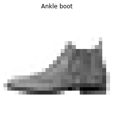

```python
# https://www.tensorflow.org/tutorials/keras/classification
class_names = ['T-shirt/top', 'Trouser', 'Pullover', 'Dress', 'Coat',
               'Sandal', 'Shirt', 'Sneaker', 'Bag', 'Ankle boot']

plt.imshow(img, cmap="binary")
plt.axis('off')
plt.title(class_names[test_labels[0]], fontsize=12)
plt.show()
```

In order to extract the feature maps we want to look at, we will create a Keras model that takes batches of images as input, and outputs the activations of all convolution and pooling layers. To do this, we will use the Keras class Model. A Model is instantiated using two arguments: an input tensor (or list of input tensors), and an output tensor (or list of output tensors). The resulting class is a Keras model, just like the Sequential models that you are familiar with, mapping the specified inputs to the specified outputs. What sets the Model class apart is that it allows for models with multiple outputs, unlike Sequential.

```python
from tensorflow.keras import models

# Extracts the outputs of the all the layers
layer_outputs = [layer.output for layer in model.layers]
# Creates a model that will return these outputs, given the model input:
activation_model = models.Model(inputs=model.input, outputs=layer_outputs)
```

Let's get the names of the layers:

```python
layer_names = []
for layer in model.layers[:7]:
    layer_names.append(layer.name)

layer_names
```

```
['conv2d',
 'max_pooling2d',
 'conv2d_1',
 'max_pooling2d_1',
 'flatten',
 'dense',
 'dense_1']
```

When fed the image input, this model returns the values of the layer activations in the original model. The model has 1 input and 7 outputs, one output per layer activation.

```python
activations = activation_model.predict(img_tensor)
len(activations)
```

```
7
```

For instance, this is the activation of the first convolution layer for our ankle boot image input:

```python
first_layer_activation = activations[0]
first_layer_activation.shape
```

```
(1, 26, 26, 32)
```

```python
third_channel = first_layer_activation[0,:, :,3]
third_channel.shape
```

```
(26, 26)
```

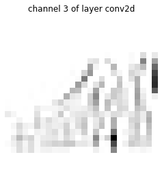

```python
import matplotlib.pyplot as plt
plt.matshow(third_channel, cmap='binary')
plt.axis('off')
plt.title(f"channel 3 of layer {layer_names[0]}", fontsize=12)
plt.show()
```

We display the activations for all the channels in the first convolution layer.

```
The feature map has shape (1, 26, 26, 32)
```

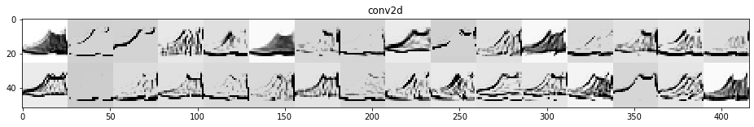

```python
images_per_row = 16

layer_name, layer_activation = layer_names[0], activations[0]

# This is the number of features in the feature map
n_features = layer_activation.shape[-1]

# The feature map has shape (1, size, size, n_features)
size = layer_activation.shape[1]

print(f"The feature map has shape (1, {size}, {size}, {n_features})")

# We will tile the activation channels in this matrix
n_cols = n_features // images_per_row
display_grid = np.zeros((size * n_cols, images_per_row * size))

# We'll tile each filter into this big horizontal grid
for col in range(n_cols):
    for row in range(images_per_row):
        channel_image = layer_activation[0,
                                         :, :,
                                         col * images_per_row + row]
        # Post-process the feature to make it visually palatable
        channel_image -= channel_image.mean()
        channel_image /= channel_image.std()
        channel_image *= 64
        channel_image += 128
        channel_image = np.clip(channel_image, 0, 255).astype('uint8')
        display_grid[col * size : (col + 1) * size,
                     row * size : (row + 1) * size] = channel_image

# Display the grid
scale = 1. / size
plt.figure(figsize=(scale * display_grid.shape[1],
                    scale * display_grid.shape[0]))
plt.title(layer_name)
plt.grid(False)
plt.imshow(display_grid, aspect='auto', cmap='binary')


plt.show()
```

We display the activations for all the channels in the first max pooling layer.

```
The feature map has shape (1, 13, 13, 32)
```

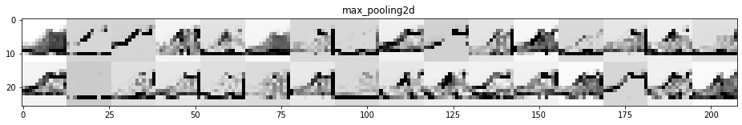

```python
images_per_row = 16

layer_name, layer_activation = layer_names[1], activations[1]

# This is the number of features in the feature map
n_features = layer_activation.shape[-1]

# The feature map has shape (1, size, size, n_features)
size = layer_activation.shape[1]

print(f"The feature map has shape (1, {size}, {size}, {n_features})")

# We will tile the activation channels in this matrix
n_cols = n_features // images_per_row
display_grid = np.zeros((size * n_cols, images_per_row * size))

# We'll tile each filter into this big horizontal grid
for col in range(n_cols):
    for row in range(images_per_row):
        channel_image = layer_activation[0,
                                         :, :,
                                         col * images_per_row + row]
        # Post-process the feature to make it visually palatable
        channel_image -= channel_image.mean()
        channel_image /= channel_image.std()
        channel_image *= 64
        channel_image += 128
        channel_image = np.clip(channel_image, 0, 255).astype('uint8')
        display_grid[col * size : (col + 1) * size,
                     row * size : (row + 1) * size] = channel_image

# Display the grid
scale = 1. / size
plt.figure(figsize=(scale * display_grid.shape[1],
                    scale * display_grid.shape[0]))
plt.title(layer_name)
plt.grid(False)
plt.imshow(display_grid, aspect='auto', cmap='binary')


plt.show()
```

We use a loop to display all the channels of all the activations in the convolution and max pooling layers. This code comes from Chapter 5 Section 4 of the Chollet book:

https://github.com/fchollet/deep-learning-with-python-notebooks/blob/master/5.4-visualizing-what-convnets-learn.ipynb

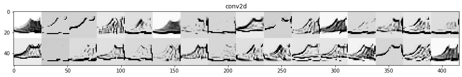

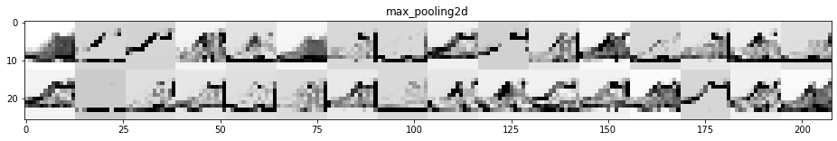

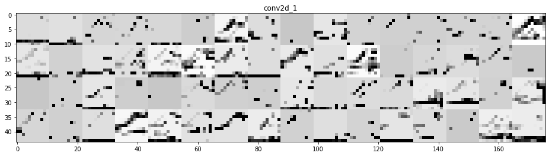

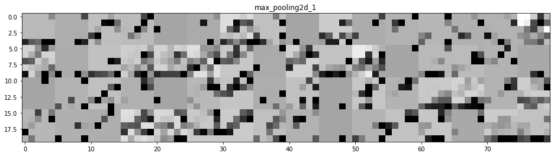

```python
# These are the names of the layers, so can have them as part of our plot
layer_names = []
for layer in model.layers:
    layer_names.append(layer.name)

images_per_row = 16

# Now let's display our feature maps
for layer_name, layer_activation in zip(layer_names, activations):

    if layer_name == 'flatten':
        break
    # This is the number of features in the feature map
    n_features = layer_activation.shape[-1]

    # The feature map has shape (1, size, size, n_features)
    size = layer_activation.shape[1]

    # We will tile the activation channels in this matrix
    n_cols = n_features // images_per_row
    display_grid = np.zeros((size * n_cols, images_per_row * size))

    # We'll tile each filter into this big horizontal grid
    for col in range(n_cols):
        for row in range(images_per_row):
            channel_image = layer_activation[0,
                                             :, :,
                                             col * images_per_row + row]
            # Post-process the feature to make it visually palatable
            channel_image -= channel_image.mean()
            channel_image /= channel_image.std()
            channel_image *= 64
            channel_image += 128
            channel_image = np.clip(channel_image, 0, 255).astype('uint8')
            display_grid[col * size : (col + 1) * size,
                         row * size : (row + 1) * size] = channel_image

    # Display the grid
    scale = 1. / size
    plt.figure(figsize=(scale * display_grid.shape[1],
                        scale * display_grid.shape[0]))
    plt.title(layer_name)
    plt.grid(False)
    plt.imshow(display_grid, aspect='auto', cmap='binary')

plt.show()
```

### EXPERIMENTAL

```python
from tensorflow.keras import backend as K
```

```python
def deprocess_image(x):
    # normalize tensor: center on 0., ensure std is 0.1
    x -= x.mean()
    x /= (x.std() + 1e-5)
    x *= 0.1

    # clip to [0, 1]
    x += 0.5
    x = np.clip(x, 0, 1)

    # convert to RGB array
    x *= 255
    x = np.clip(x, 0, 255).astype('uint8')
    return x
```

```python
def generate_pattern(layer_name, filter_index, size=28):
    # Build a loss function that maximizes the activation
    # of the nth filter of the layer considered.
    layer_output = model.get_layer(layer_name).output
    loss = K.mean(layer_output[:, :, :, filter_index])

    # Compute the gradient of the input picture wrt this loss
    grads = K.gradients(loss, model.input)[0]

    # Normalization trick: we normalize the gradient
    grads /= (K.sqrt(K.mean(K.square(grads))) + 1e-5)

    # This function returns the loss and grads given the input picture
    iterate = K.function([model.input], [loss, grads])

    # We start from a gray image with some noise
    input_img_data = np.random.random((1, size, size, 1)) * 20 + 128.

    # Run gradient ascent for 40 steps
    step = 1.
    for i in range(40):
        loss_value, grads_value = iterate([input_img_data])
        input_img_data += grads_value * step

    img = input_img_data[0]
    return deprocess_image(img)
```

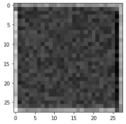

```python
from tensorflow.keras.preprocessing import image
import numpy as np


plt.imshow(generate_pattern('conv2d',0).reshape(28,28), cmap="binary")
```

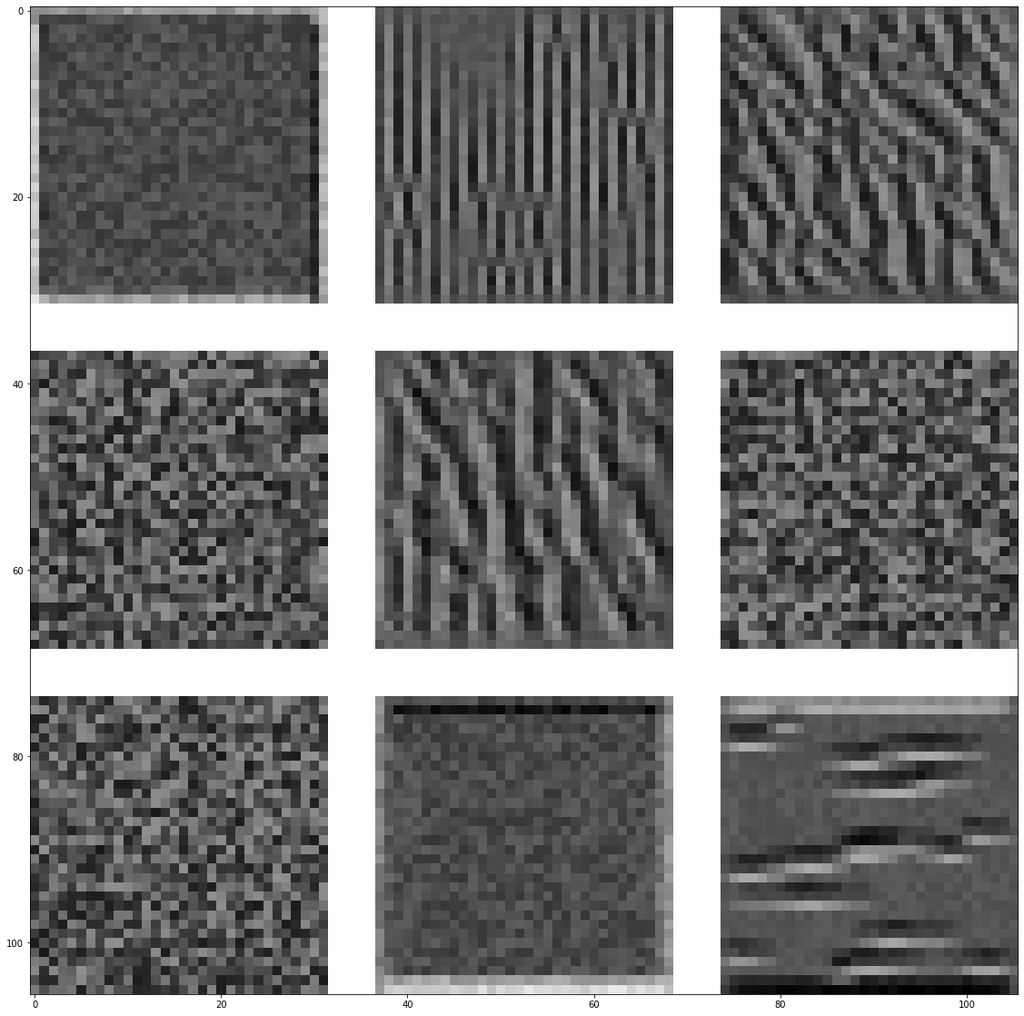

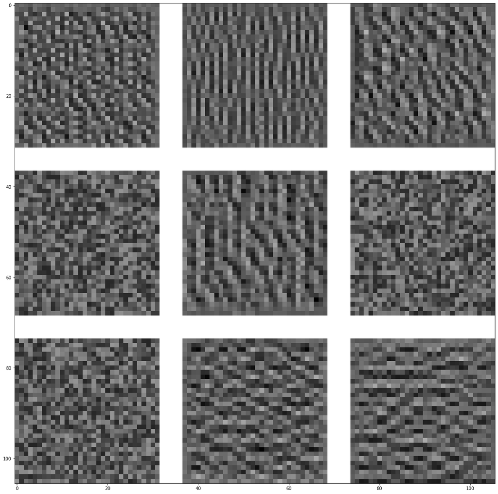

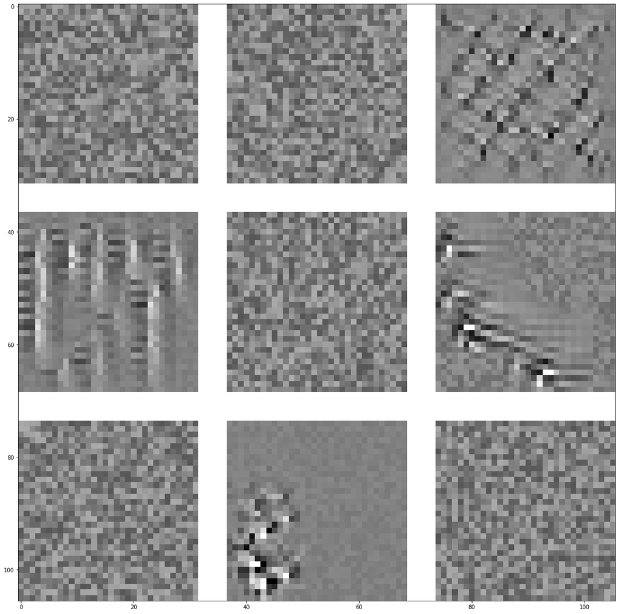

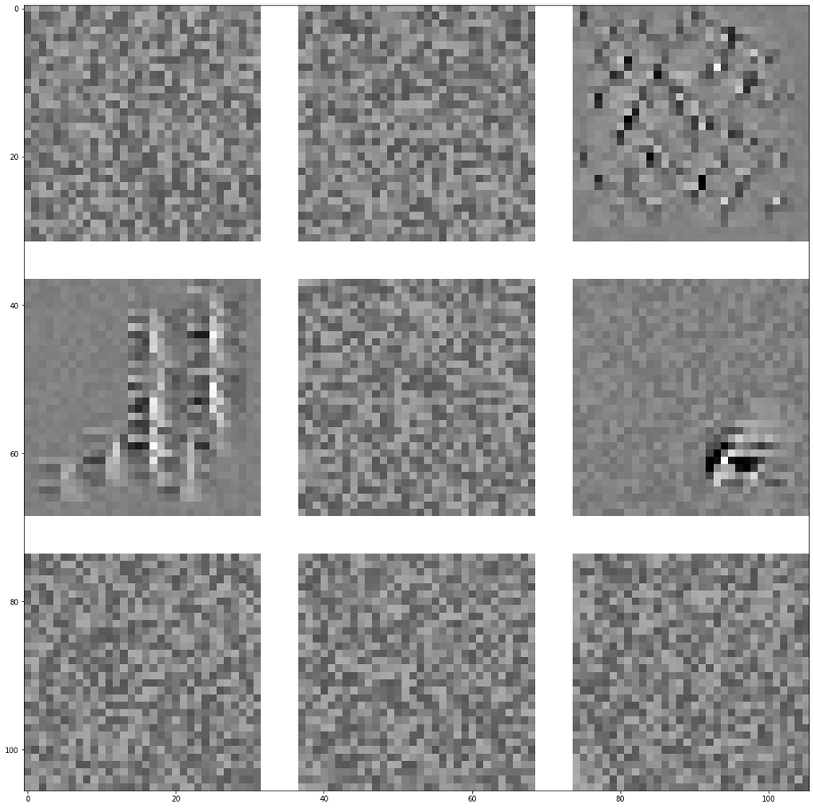

```python
for layer_name in ['conv2d', 'max_pooling2d', 'conv2d_1', 'max_pooling2d_1']:
    size = 32
    margin = 5

    # This a empty (black) image where we will store our results.
    results = np.zeros((3 * size + 2 * margin, 3 * size + 2 * margin, 1))

    for i in range(3):  # iterate over the rows of our results grid
        for j in range(3):  # iterate over the columns of our results grid
            # Generate the pattern for filter `i + (j * 3)` in `layer_name`
            filter_img = generate_pattern(layer_name, i + (j * 3), size=size)

            #filter_img = filter_img.reshape(32,32)

            # Put the result in the square `(i, j)` of the results grid
            horizontal_start = i * size + i * margin
            horizontal_end = horizontal_start + size
            vertical_start = j * size + j * margin
            vertical_end = vertical_start + size
            results[horizontal_start: horizontal_end, vertical_start: vertical_end, :] = filter_img

    # Display the results grid
    plt.figure(figsize=(20, 20))
    plt.imshow(results.reshape(106,106),cmap="binary")
    plt.show()
```